# Assignment 3

Dans Lismanis

2023-10-15

# Practical Questions:

## Question 1:

### a)

Quantiles for HHLarge:

```r
df=read.csv("oj.csv")
quantile(df$HHLARGE)
```

```
##         0%        25%        50%        75%       100%
## 0.01350636 0.09793763 0.11122120 0.13516767 0.21635434
```

Mean:

```r
mean(df$HHLARGE)
```

```
## [1] 0.1156024
```

```r
df=read.csv("oj.csv")
quantile(df$EDUC)
```

```
##         0%        25%        50%        75%       100%
## 0.04955029 0.14598490 0.22939040 0.28439465 0.52836201
```

Mean:

```r
mean(df$EDUC)
```

```
## [1] 0.2252196
```

### b)

#### I)

```r
lp=log(df$price)
library(fastDummies)
df=dummy_cols(df, select_columns ='brand')
df$featdom=df$feat*df$brand_dominicks
df$featminu=df$feat*df$brand_minute.maid
df$feattro=df$feat*df$brand_tropicana

df$dom_lp=lp*df$brand_dominicks
df$min_lp=lp*df$brand_minute.maid
df$tro_lp=lp*df$brand_tropicana

reg9a=lm(logmove~ lp+min_lp+tro_lp+featdom+featminu+feattro+AGE60+EDUC+ETHNIC+INCOME+HHLARGE+WORKWOM+HVAL150, data=df)
summary(reg9a)
```

```
##
## Call:
## lm(formula = logmove ~ lp + min_lp + tro_lp + featdom + featminu +
##     feattro + AGE60 + EDUC + ETHNIC + INCOME + HHLARGE + WORKWOM +
##     HVAL150, data = df)
##
## Residuals:
##     Min      1Q  Median      3Q     Max
## -5.3436 -0.4044  0.0035  0.4019  3.0209
##
## Coefficients:
##             Estimate Std. Error  t value Pr(>|t|)
## (Intercept) 12.25036    0.31569   38.805  < 2e-16 ***
## lp          -3.33228    0.02712 -122.860  < 2e-16 ***
## min_lp       0.96575    0.01713   56.365  < 2e-16 ***
## tro_lp       1.60123    0.01751   91.463  < 2e-16 ***
## featdom      0.77982    0.01586   49.179  < 2e-16 ***
## featminu     1.12669    0.01488   75.725  < 2e-16 ***
## feattro      0.72941    0.01834   39.764  < 2e-16 ***
## AGE60        1.49973    0.12780   11.735  < 2e-16 ***
## EDUC         0.47215    0.10092    4.679 2.90e-06 ***
## ETHNIC       0.57968    0.03640   15.925  < 2e-16 ***
## INCOME      -0.13735    0.03162   -4.344 1.40e-05 ***
## HHLARGE     -1.22207    0.23557   -5.188 2.14e-07 ***
## WORKWOM     -1.34759    0.14407   -9.354  < 2e-16 ***
## HVAL150      0.39359    0.04062    9.690  < 2e-16 ***
## ---
## Signif. codes:  0 '***' 0.001 '**' 0.01 '*' 0.05 '.' 0.1 ' ' 1
##
## Residual standard error: 0.6794 on 28933 degrees of freedom
## Multiple R-squared:  0.5561, Adjusted R-squared:  0.5559
## F-statistic:  2788 on 13 and 28933 DF,  p-value: < 2.2e-16
```

```r
CoefH=coef(reg9a)['HHLARGE']
CoefH
```

```
##   HHLARGE
## -1.222074
```

```r
medH=median(df$HHLARGE)
thirdqH=quantile(df$HHLARGE,0.75)
deltalogq=CoefH*(thirdqH-medH)
deltalogq
```

```
##     HHLARGE
## -0.02926436
```

#### II)

```r
CoefE=coef(reg9a)["EDUC"]
medE=median(df$EDUC)
thirdqE=quantile(df$EDUC,0.75)
deltalogqE=CoefE*(thirdqE-medE)
deltalogqE
```

```
##       EDUC
## 0.02597016
```

#### III)

The absolute value of change is greater for HHLARGE so we conclude that this is the more important predictor of demand.

### c)

#### I)

```r
df$EDUC_lp=df$EDUC*lp
df$HHLARGE_lp=df$HHLARGE*lp
reg1c=lm(logmove ~ lp+min_lp+tro_lp+featdom+featminu+feattro+AGE60+EDUC+ETHNIC+INCOME+HHLARGE+WORKWOM+HVAL150+EDUC_lp+HHLARGE_lp, data=df)
summary(reg1c)
```

```
##
## Call:
## lm(formula = logmove ~ lp + min_lp + tro_lp + featdom + featminu +
##     feattro + AGE60 + EDUC + ETHNIC + INCOME + HHLARGE + WORKWOM +
##     HVAL150 + EDUC_lp + HHLARGE_lp, data = df)
##
## Residuals:
##     Min      1Q  Median      3Q     Max
## -5.7175 -0.3930 -0.0011  0.3889  2.9202
##
## Coefficients:
##             Estimate Std. Error t value Pr(>|t|)
## (Intercept) 12.32064    0.31646  38.932  < 2e-16 ***
## lp          -3.58921    0.07683 -46.716  < 2e-16 ***
## min_lp       0.97070    0.01677  57.894  < 2e-16 ***
## tro_lp       1.60982    0.01713  93.960  < 2e-16 ***
## featdom      0.77753    0.01552  50.109  < 2e-16 ***
## featminu     1.12793    0.01456  77.469  < 2e-16 ***
## feattro      0.72948    0.01795  40.640  < 2e-16 ***
## AGE60        1.50606    0.12507  12.042  < 2e-16 ***
## EDUC        -2.42582    0.14362 -16.890  < 2e-16 ***
## ETHNIC       0.60309    0.03564  16.921  < 2e-16 ***
## INCOME      -0.12893    0.03097  -4.164 3.14e-05 ***
## HHLARGE      2.79760    0.44088   6.346 2.25e-10 ***
## WORKWOM     -1.27107    0.14101  -9.014  < 2e-16 ***
## HVAL150      0.41598    0.03975  10.465  < 2e-16 ***
## EDUC_lp      3.59458    0.13139  27.359  < 2e-16 ***
## HHLARGE_lp  -4.99739    0.47770 -10.461  < 2e-16 ***
## ---
## Signif. codes:  0 '***' 0.001 '**' 0.01 '*' 0.05 '.' 0.1 ' ' 1
##
## Residual standard error: 0.6648 on 28931 degrees of freedom
## Multiple R-squared:  0.5749, Adjusted R-squared:  0.5747
## F-statistic:  2609 on 15 and 28931 DF,  p-value: < 2.2e-16
```

#### II)

Yes, these coefficients make sense as when a household is large and the price of the product is increased the demand for it drops significantly. As the bigger the hausehold is the more they would feel the impact of price change.

#### III)

After adding interaction therms the coefficients of EDUC and HHLARGE increased in absolute value, the signs of the coefficients have changed.

#### IV)

```r
elmedH=coef(reg1c)["HHLARGE"]*(medH/median(df$logmove))
elmedE=coef(reg1c)["EDUC"]*(medE/median(df$logmove))
el75H=coef(reg1c)["HHLARGE"]*(thirdqH/median(df$logmove))
el75E=coef(reg1c)["EDUC"]*(thirdqE/median((df$logmove)))
deltaE=((el75E-elmedE)/elmedE)
deltaH=(el75H-elmedH)/elmedH
deltaE
```

```
##      EDUC
## 0.2397844
```

```r
deltaH
```

```
##   HHLARGE
## 0.2153049
```

Education is more important as the percentage change is higher.

## Question 2

### a)

```r
df1=df
df1$week=df1$week+1
df2=merge(df,df1, by=c("brand","store","week"))
colnames(df2)[colnames(df2)=="price.y"]="LagPrice"
colnames(df2)[colnames(df2)=="price.x"]="Price"
df2$LnPrice=log(df2$Price)
df2$LnLagPrice=log(df2$LagPrice)
```

### b)

```r
reg2b=lm(logmove.x~LnPrice+LnLagPrice,data=df2)
summary(reg2b)
```

```
##
## Call:
## lm(formula = logmove.x ~ LnPrice + LnLagPrice, data = df2)
##
## Residuals:
##     Min      1Q  Median      3Q     Max
## -4.9174 -0.5173 -0.0191  0.5085  3.7825
##
## Coefficients:
##             Estimate Std. Error t value Pr(>|t|)
## (Intercept)  9.98930    0.01536  650.30   <2e-16 ***
## LnPrice     -2.79038    0.02295 -121.56   <2e-16 ***
## LnLagPrice   1.74826    0.02285   76.51   <2e-16 ***
## ---
## Signif. codes:  0 '***' 0.001 '**' 0.01 '*' 0.05 '.' 0.1 ' ' 1
##
## Residual standard error: 0.825 on 28005 degrees of freedom
## Multiple R-squared:  0.3461, Adjusted R-squared:  0.3461
## F-statistic:  7412 on 2 and 28005 DF,  p-value: < 2.2e-16
```

We can see that the estimated coefficient of logorith of last weeks price is positive, this indicates that an increase of price in the previous week leads to a increase of demand this week. This makes sales more attractive, as increase of the price last week does not lead to decrease of sales this week.

## Question 3

### a)

```r
library(fastDummies)
df2=dummy_cols(df2, select_columns ='brand')
df2$min_lp=df2$brand_dominicks*df2$LnPrice
df2$min_laglp=df2$brand_dominicks*df2$LnLagPrice
df2$tro_lp=df2$brand_tropicana*df2$LnPrice
df2$tro_laglp=df2$brand_tropicana*df2$LnLagPrice
df2$EDUC_lp=df2$EDUC.x*df2$LnPrice
df2$HHLarge_lp=df2$HHLARGE.x*df2$LnPrice
sampsize=nrow(df2)/5
all=1:nrow(df2)
inc=c(1:sampsize,(sampsize+1):(2*sampsize),(2*sampsize+1):(3*sampsize),(3*sampsize+1):(4*sampsize),(4*sampsize+1):(nrow(df2)))
indices=sample(1:nrow(df2))
part1=df2[indices[1:sampsize],]
part2=df2[indices[(sampsize+1):(2*sampsize)],]
part3=df2[indices[(2*sampsize+1):(3*sampsize)],]
part4=df2[indices[(3*sampsize+1):(4*sampsize)],]
part5=df2[indices[(4*sampsize+1):(nrow(df2))],]
```

### b)

```r
train1=rbind(part2,part3,part4,part5)
test1=part1
train2=rbind(part1,part3,part4,part5)
test2=part2
train3=rbind(part1,part2,part4,part5)
test3=part3
train4=rbind(part1,part2,part3,part5)
test4=part4
train5=rbind(part1,part2,part3,part4)
test5=part5
```

### c)

```r
train1reg=lm(logmove.x~ LnPrice+LnLagPrice+min_lp+min_laglp+tro_lp+tro_laglp+feat.x+brand_minute.maid+brand_tropicana+AGE60.x+EDUC.x+EDUC_lp.x+ETHNIC.x+INCOME.x+HHLARGE.x+HHLARGE_lp.x+WORKWOM.x+HVAL150.x, data=train1)
MSE_train1=mean((train1$logmove.x-predict(train1reg))^2)
MSE_train1
```

```
## [1] 0.4336338
```

```r
test1reg=lm(logmove.x~ LnPrice+LnLagPrice+min_lp+min_laglp+tro_lp+tro_laglp+feat.x+brand_minute.maid+brand_tropicana+AGE60.x+EDUC.x+EDUC_lp.x+ETHNIC.x+INCOME.x+HHLARGE.x+HHLARGE_lp.x+WORKWOM.x+HVAL150.x, data=test1)
MSE_test1=mean((test1$logmove.x-predict(test1reg))^2)
MSE_test1
```

```
## [1] 0.402341
```

```r
train2reg=lm(logmove.x~ LnPrice+LnLagPrice+min_lp+min_laglp+tro_lp+tro_laglp+feat.x+brand_minute.maid+brand_tropicana+AGE60.x+EDUC.x+EDUC_lp.x+ETHNIC.x+INCOME.x+HHLARGE.x+HHLARGE_lp.x+WORKWOM.x+HVAL150.x, data=train2)
MSE_train2=mean((train2$logmove.x-predict(train2reg))^2)
MSE_train2
```

```
## [1] 0.4255433
```

```r
test2reg=lm(logmove.x~ LnPrice+LnLagPrice+min_lp+min_laglp+tro_lp+tro_laglp+feat.x+brand_minute.maid+brand_tropicana+AGE60.x+EDUC.x+EDUC_lp.x+ETHNIC.x+INCOME.x+HHLARGE.x+HHLARGE_lp.x+WORKWOM.x+HVAL150.x, data=test2)
MSE_test2=mean((test2$logmove.x-predict(test2reg))^2)
MSE_test2
```

```
## [1] 0.4339276
```

```r
train3reg=lm(logmove.x~ LnPrice+LnLagPrice+min_lp+min_laglp+tro_lp+tro_laglp+feat.x+brand_minute.maid+brand_tropicana+AGE60.x+EDUC.x+EDUC_lp.x+ETHNIC.x+INCOME.x+HHLARGE.x+HHLARGE_lp.x+WORKWOM.x+HVAL150.x, data=train3)
MSE_train3=mean((train3$logmove.x-predict(train3reg))^2)
MSE_train3
```

```
## [1] 0.4221118
```

```r
test3reg=lm(logmove.x~ LnPrice+LnLagPrice+min_lp+min_laglp+tro_lp+tro_laglp+feat.x+brand_minute.maid+brand_tropicana+AGE60.x+EDUC.x+EDUC_lp.x+ETHNIC.x+INCOME.x+HHLARGE.x+HHLARGE_lp.x+WORKWOM.x+HVAL150.x, data=test3)
MSE_test3=mean((test3$logmove.x-predict(test3reg))^2)
MSE_test3
```

```
## [1] 0.4472719
```

```r
train4reg=lm(logmove.x~ LnPrice+LnLagPrice+min_lp+min_laglp+tro_lp+tro_laglp+feat.x+brand_minute.maid+brand_tropicana+AGE60.x+EDUC.x+EDUC_lp.x+ETHNIC.x+INCOME.x+HHLARGE.x+HHLARGE_lp.x+WORKWOM.x+HVAL150.x, data=train4)
MSE_train4=mean((train4$logmove.x-predict(train4reg))^2)
MSE_train4
```

```
## [1] 0.4273048
```

```r
test4reg=lm(logmove.x~ LnPrice+LnLagPrice+min_lp+min_laglp+tro_lp+tro_laglp+feat.x+brand_minute.maid+brand_tropicana+AGE60.x+EDUC.x+EDUC_lp.x+ETHNIC.x+INCOME.x+HHLARGE.x+HHLARGE_lp.x+WORKWOM.x+HVAL150.x, data=test4)
MSE_test4=mean((test4$logmove.x-predict(test4reg))^2)
MSE_test4
```

```
## [1] 0.4252501
```

```r
train5reg=lm(logmove.x~ LnPrice+LnLagPrice+min_lp+min_laglp+tro_lp+tro_laglp+feat.x+brand_minute.maid+brand_tropicana+AGE60.x+EDUC.x+EDUC_lp.x+ETHNIC.x+INCOME.x+HHLARGE.x+HHLARGE_lp.x+WORKWOM.x+HVAL150.x, data=train5)
MSE_train5=mean((train5$logmove.x-predict(train5reg))^2)
MSE_train5
```

```
## [1] 0.4288663
```

```r
test5reg=lm(logmove.x~ LnPrice+LnLagPrice+min_lp+min_laglp+tro_lp+tro_laglp+feat.x+brand_minute.maid+brand_tropicana+AGE60.x+EDUC.x+EDUC_lp.x+ETHNIC.x+INCOME.x+HHLARGE.x+HHLARGE_lp.x+WORKWOM.x+HVAL150.x, data=test5)
MSE_test5=mean((test5$logmove.x-predict(test5reg))^2)
MSE_test5
```

```
## [1] 0.4211083
```

```r
avgMSE=(MSE_test1+MSE_train1+MSE_test2+MSE_train2+MSE_test3+MSE_train3+MSE_test4+MSE_train4+MSE_test5+MSE_train5)/10
avgMSE
```

```
## [1] 0.4267359
```

# Theotethical Questions:

## Question 1

### a)

I would regress the quantity sold of orange juice on the price of the orange juice and the quantity sold of bananas.  
Then I would look at the sign of quantity bananas sold coefficient, if it is positive then they are complements, if negative then substitutes.

### b)

The sign of the coefficient would be negative. As they are substitutes you are more likely to bundle them.

#### I)

This is due to the fact that that now you can sell more products, as now the person who only wanted bananas is inclined to buy the bundle with orange juice as well.

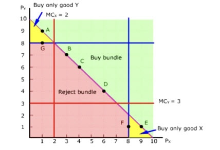

#### II)

The price of the bundle would be less than the sum of the two independent prices.

### c)

We are assuming that orange juice and bananas are substitutes.

This would cause an increase in the quantity sold of the orange juice, but also decrease the sales of bananas as they are substitutes and orange juice is offered at a lower price than usual.

If we keep the price of the bundle as before it becomes less attractive to the consumer, so we could decrease the price of the bundle consistently with the sale of orange juice to keep it still attractive.